# Comparison of Polymethylation score options

Freida Blostein

February 04, 2021

## 0.1 Function code

I created a function based on Jonah’s code that takes in as an option the transformation type for the methylation beta matrix, and applies it before creating the polymethylation scores. The code is available at https://github.com/blostein/FFSmoking/blob/main/UsefulCode/makePolyEpiScores.R

```r
#' Title
#'
#' @param m a matrix; cleaned matrix of methylation values (0-1) from your data where rows are cpg sites and columns are samples; rownames should be of format cg########
#' @param b a list; a list of dataframes containing a column CpG with cpg sites named in format cg######## and a column Coef containing relavent coeficient, should be a named list (names will become score names)
#' @param transformopt character, the method for transforming the m values, default none, options zscore or meancenter
#'
#' @return scores
#' @export
#'
#' @examples
makePolyEpiScore<-function(m, b, transformopt='none'){
  #check inputs
  try(if(is.matrix(m)==F) stop('m is not a matrix'))
  try(if(is.list(b)==F) stop('b is not a list'))
  if(is.null(names(b))){names(b)=paste0('option', 1:length(b))}
  #generate poly methylation scores
  scores<-lapply(b, function(x){
    commonp<-Reduce(intersect,list(x%>%filter(!is.na(Coef))%>%pull(`CpG`), rownames(m)))%>% unique # filter to non-missing shared cpg sites
    beta1<-m[match(commonp, rownames(m)),] #pull shared cpg sites from methylation matrix
    #apply transform to cpgs of the cleaned methylation matrix
    print(paste0('transforming the methylation matrix:', transformopt))
    if(transformopt=='zscore'){beta1=t(scale(t(beta1)))} #center and scale the rows (cpgs) of the (shared cpg sites) methylation matrix
    if(transformopt=='meancenter'){beta1=t(scale(t(beta1), center=T, scale=F))} #center the rows (cpgs) of (shared cpgs sites) methylation matrix only
    x1<-x %>% filter(`CpG` %in% commonp) #pull shared cpg sites from coeficient matrix
    (as.numeric(x1[['Coef']]) %*% beta1)%>%unlist%>%c #matrix multiplication of shared coeficients and shared methylation
  })%>% bind_cols()
  return(scores)
}
```

A few notes on this code:

1. because the methylation matrix is so large, RStudio kept crashing when I attempted to zscore standardize or center-mean standardize the entire matrix. So, instead, I performed the standardization inside the loop, only upon the CpGs that are used in making each polymethylation scores. Since I think we should be standardizing CpGs, not standardizing individuals, this shouldn’t matter.
2. Currently only 2 standardization options but could add more.

## 0.2 Distributions of poly methylation scores with different transformations on beta methylation matrix

```r
lapply(polyscores, function(x){summary(x)})
```

```
## $notransform
##    anynewborn      SSnewborn      SSnewbornCT       SSolder
##  Min.   :1.089   Min.   :1.401   Min.   :1.768   Min.   :1.388
##  1st Qu.:1.648   1st Qu.:2.177   1st Qu.:2.285   1st Qu.:2.204
##  Median :1.804   Median :2.401   Median :2.433   Median :2.370
##  Mean   :1.799   Mean   :2.393   Mean   :2.437   Mean   :2.357
##  3rd Qu.:1.944   3rd Qu.:2.596   3rd Qu.:2.586   3rd Qu.:2.525
##  Max.   :3.336   Max.   :4.486   Max.   :3.690   Max.   :3.033
##     MethID
##  Length:1776
##  Class :character
##  Mode  :character
##
##
##
##
## $zscore
##    anynewborn        SSnewborn         SSnewbornCT          SSolder
##  Min.   :-9.2702   Min.   :-13.0444   Min.   :-9.81548   Min.   :-10.627
##  1st Qu.:-2.0478   1st Qu.: -2.9093   1st Qu.:-2.30422   1st Qu.: -1.972
##  Median : 0.1048   Median :  0.1805   Median :-0.02733   Median :  0.108
##  Mean   : 0.0000   Mean   :  0.0000   Mean   : 0.00000   Mean   :  0.000
##  3rd Qu.: 2.0561   3rd Qu.:  2.7884   3rd Qu.: 2.18786   3rd Qu.:  2.001
##  Max.   :26.8843   Max.   : 36.2332   Max.   :20.81176   Max.   : 10.562
##     MethID
##  Length:1776
##  Class :character
##  Mode  :character
##
##
##
##
## $center
##    anynewborn         SSnewborn          SSnewbornCT           SSolder
##  Min.   :-0.70990   Min.   :-0.991518   Min.   :-0.668202   Min.   :-0.96822
##  1st Qu.:-0.15031   1st Qu.:-0.215836   1st Qu.:-0.151201   1st Qu.:-0.15303
##  Median : 0.00566   Median : 0.008696   Median :-0.003795   Median : 0.01289
##  Mean   : 0.00000   Mean   : 0.000000   Mean   : 0.000000   Mean   : 0.00000
##  3rd Qu.: 0.14522   3rd Qu.: 0.203572   3rd Qu.: 0.149063   3rd Qu.: 0.16793
##  Max.   : 1.53701   Max.   : 2.093416   Max.   : 1.253064   Max.   : 0.67688
##     MethID
##  Length:1776
##  Class :character
##  Mode  :character
##
##
##
```

```r
lapply(polyscores, function(x){apply(x, 2, sd)})
```

```
## $notransform
##  anynewborn   SSnewborn SSnewbornCT     SSolder      MethID
##   0.2180485   0.3052760   0.2280880   0.2620030          NA
##
## $zscore
##  anynewborn   SSnewborn SSnewbornCT     SSolder      MethID
##    2.942183    4.113377    3.312178    3.126625          NA
##
## $center
##  anynewborn   SSnewborn SSnewbornCT     SSolder      MethID
##   0.2180485   0.3052760   0.2280880   0.2620030          NA
```

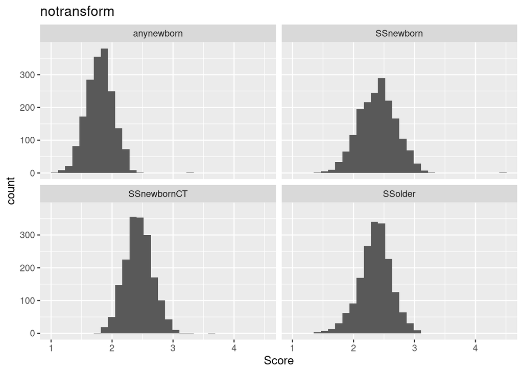

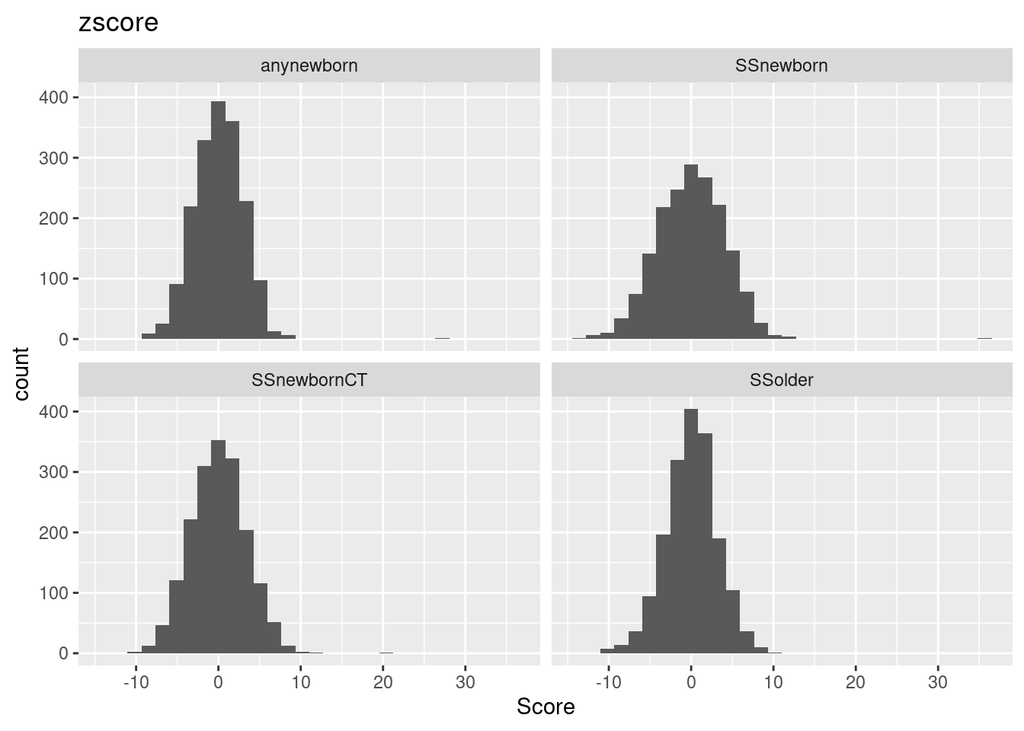

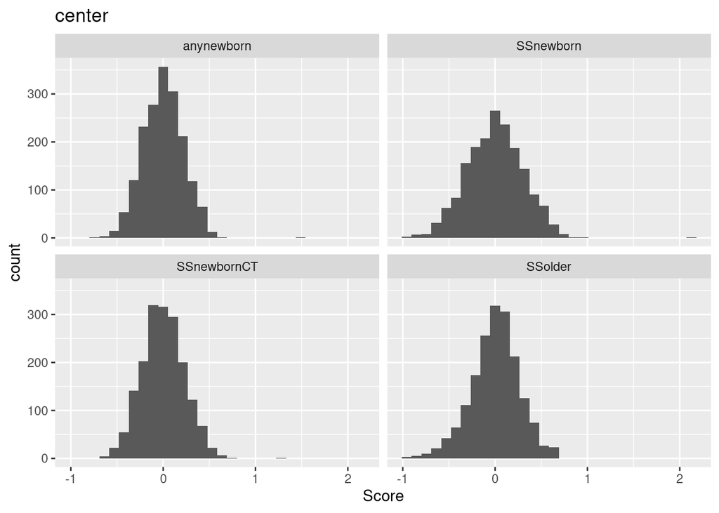

```r
lapply(seq_along(polyscores), function(i){polyscores[[i]]%>%pivot_longer(cols=1:4, names_to='Score_Type', values_to='Score')%>%ggplot(aes(x=Score))+geom_histogram()+facet_wrap(~Score_Type)+ggtitle(names(polyscores)[[i]])})
```

As Kelly thought, the zscore standardized have a larger range and the biggest standard deviations, the standard deviations of the no transform and centered methods are the same, which makes sense (I think) as $V(aX+b)=a^2V(X)\implies V(\sum\beta_i*[x_i-\bar{x}])=V(\sum\beta_i*x_i-\beta_i*\bar{x})=V(\sum \beta_i*x_i-k)=V(\sum \beta_i*x_i)$.

I think it also makes sense the means of the mean centered and zscores standardized scores are 0.

## 0.3 Correlation between polymethylation scores of different transforms on the beta methylation matrix

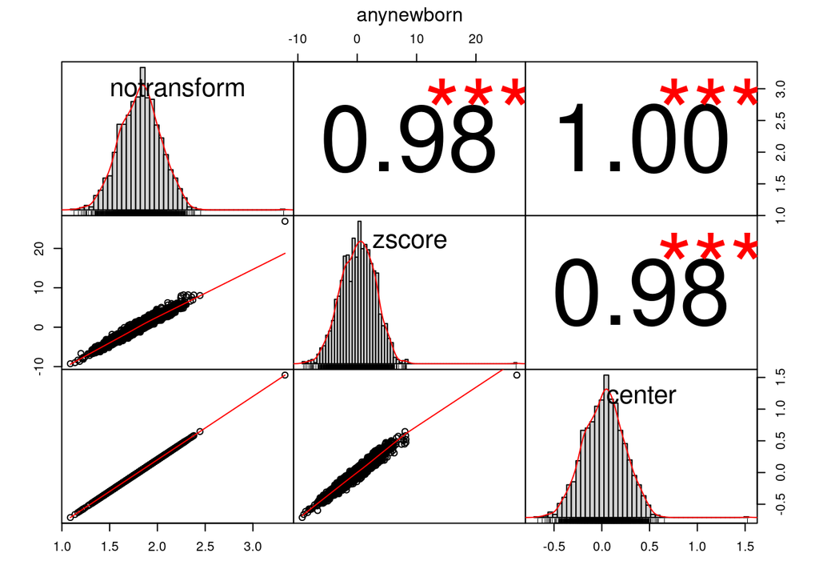

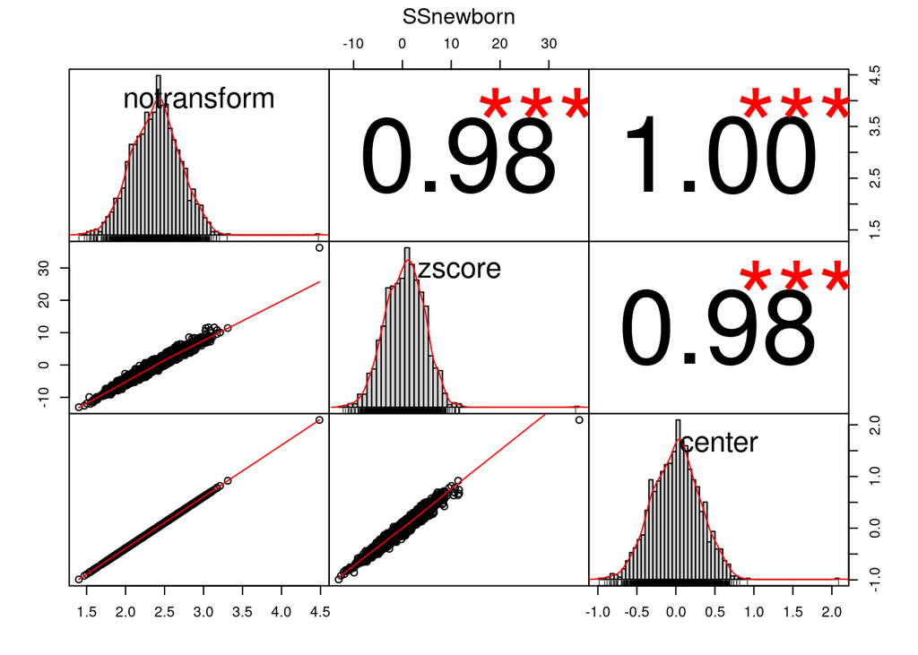

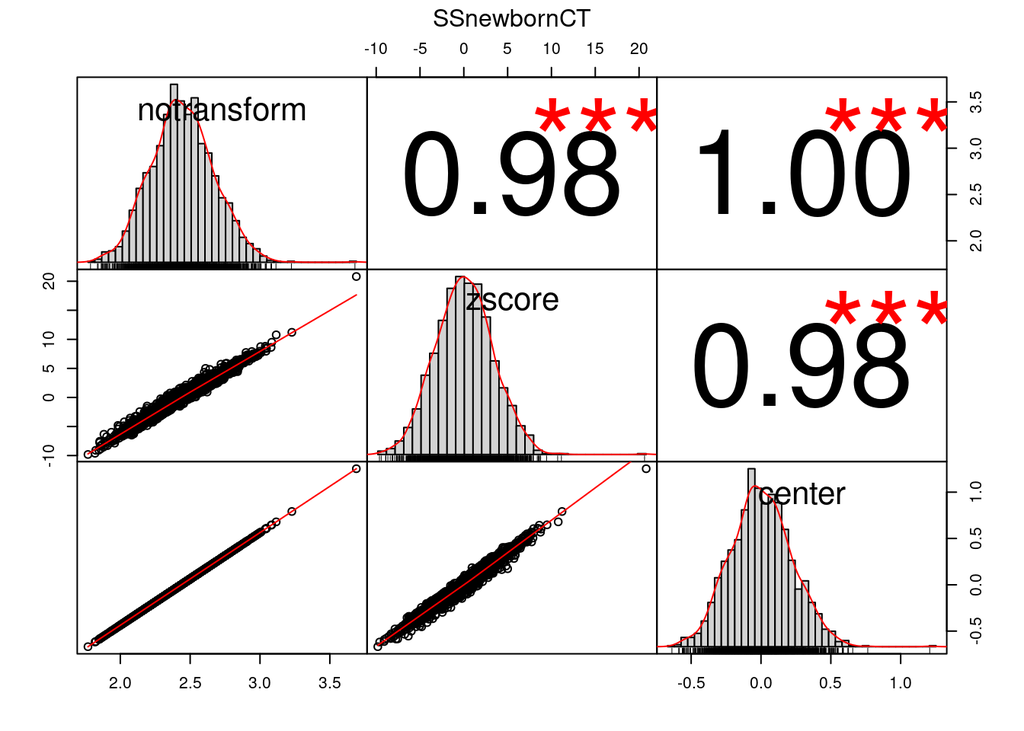

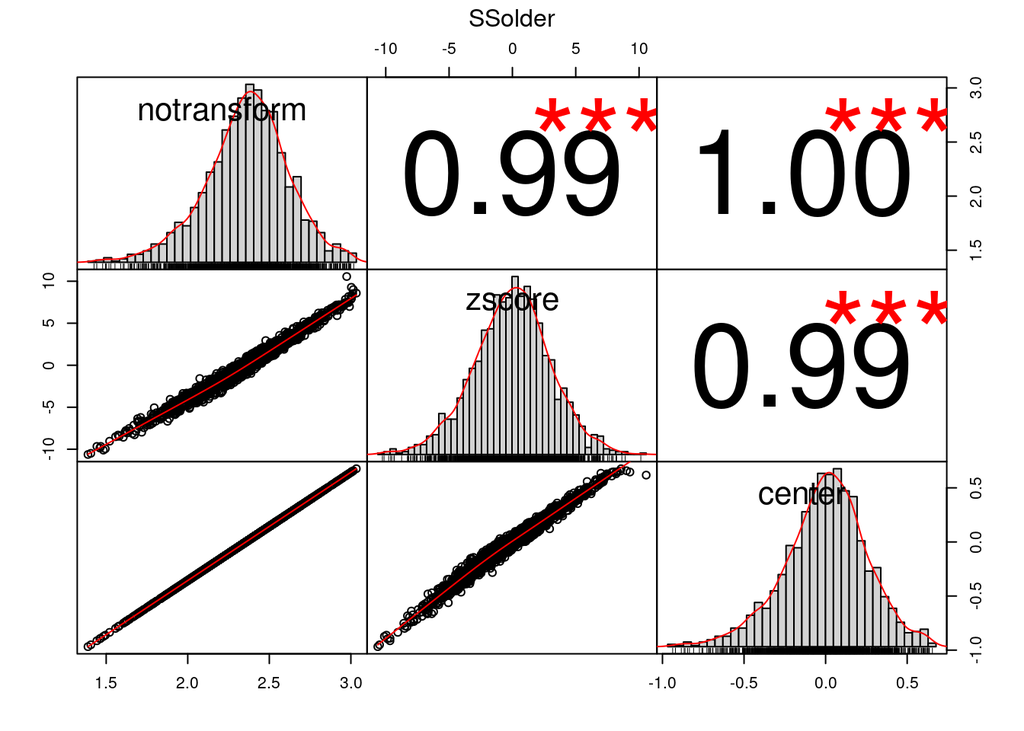

```r
polyscores_flipped=lapply(seq_along(polyscores), function(i){polyscores[[i]]%>%mutate('method'=names(polyscores)[[i]])%>%pivot_longer(cols=1:4, names_to="Score_type", values_to="Score")})%>%bind_rows()%>%pivot_wider(id_cols=c(MethID, Score_type), names_from='method', values_from='Score')%>%group_by(Score_type)%>%group_split()
names(polyscores_flipped)=lapply(polyscores_flipped, function(x){x$Score_type%>%unique()})

lapply(seq_along(polyscores_flipped), function(i){chart.Correlation(polyscores_flipped[[i]][3:5]); mtext(names(polyscores_flipped)[[i]], side=3, line=3)})
```

## 0.4 Question for Kelly:

These polymethylation scores calculated on non-COMBAT corrected methylation beta values - should they also be calculated using COMBAT (or SVA) -corrected beta values?

## 0.5 Bivariate analysis of polymethylation scores w/ different transformations & binary prenatal smoking variable

```r
load(file.path(datadir, 'CreatedData', 'BaseModelData.Rdata'))
polyscores_flipped<-lapply(polyscores_flipped, function(x) left_join(basemodeldata, x))
```

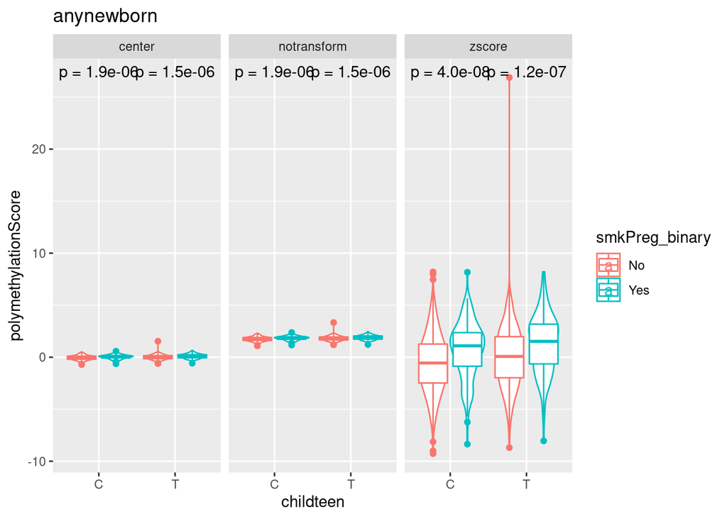

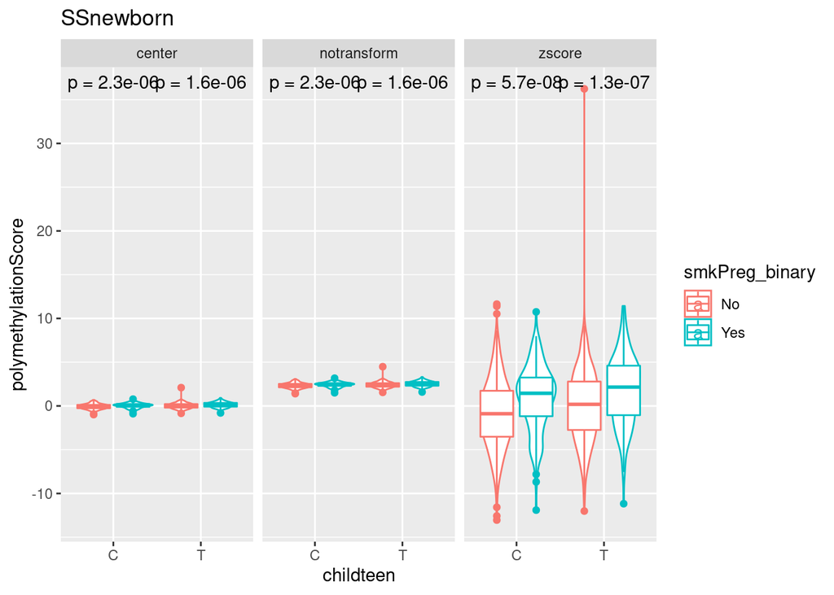

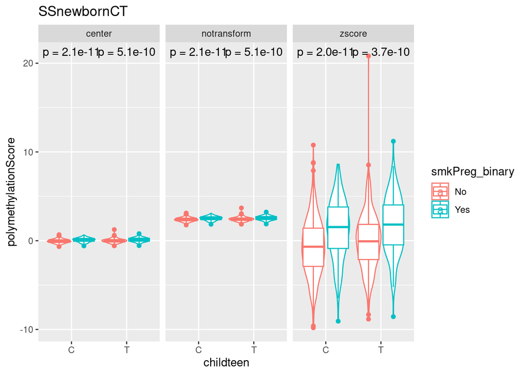

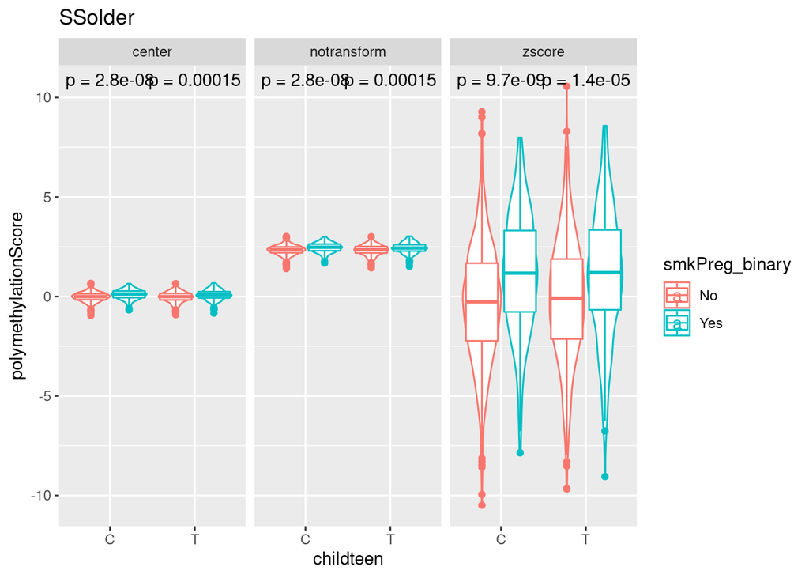

```r
lapply(seq_along(polyscores_flipped), function(i) ggplot(polyscores_flipped[[i]]%>%pivot_longer(cols=notransform:center, names_to='transformType', values_to='polymethylationScore'), aes(x=childteen, y=polymethylationScore, color=smkPreg_binary))+geom_violin()+geom_boxplot(position=position_dodge(width=0.9))+facet_wrap(~transformType)+stat_compare_means(label='p.format')+ggtitle(names(polyscores_flipped)[i]))
```